[OHI Science](http://ohi-science.org) | [Citation policy](http://ohi-science.org/citation-policy/)

# OHI 2021: LSP Updates Check

Compiled on Tue Feb 16 09:46:33 2021 by sgclawson

# Summary

Check outliers in output files from Lasting Special Places data prep and compare to Protected Planet’s [monthly updates](https://www.protectedplanet.net/c/monthly-updates/) webpage.

```r
major_changes <- read_csv("output/major_changes_2021.csv" ) #added this so I could come back to it without rerunning everything
```

## Bouvet Island +1.0:

- Everything I can find suggests that this is and has been a fully protected nature preserve.
- It could be possible that in the past our models somehow were ignoring this place?

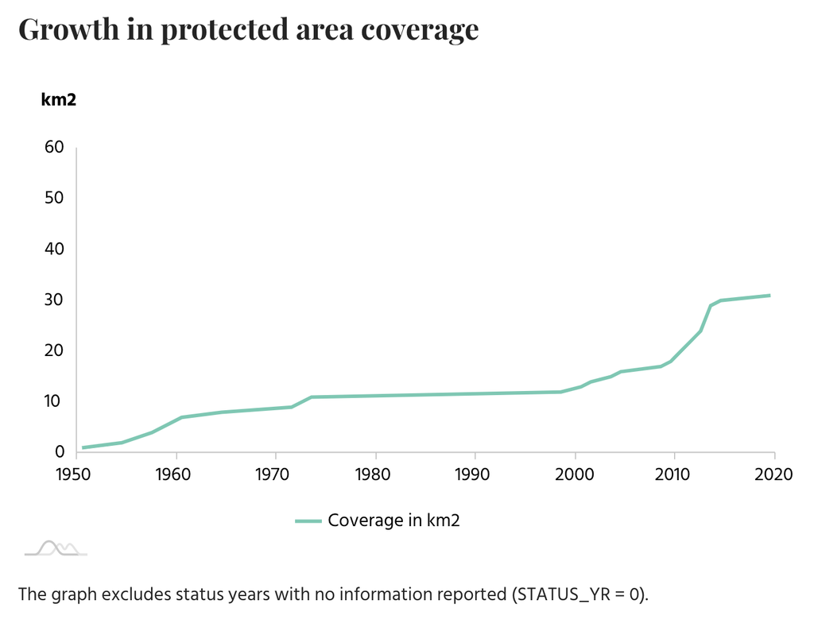

## Russia +0.667:

- At first glance, this one is a little puzzling…
- The chart here also doesn’t reflect that big of growth:

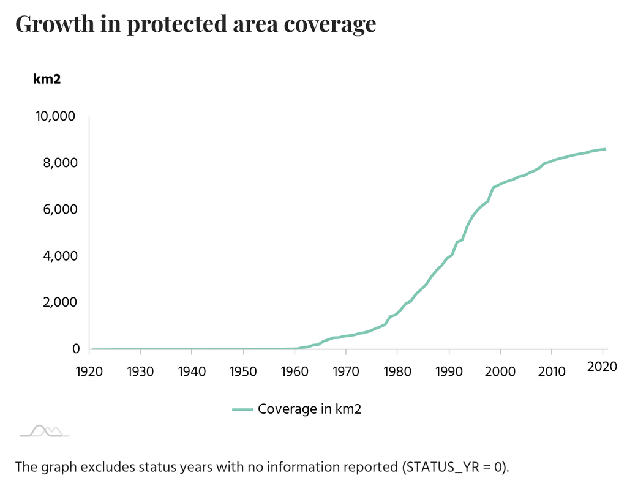

- And on the [country page for protected planet](https://www.protectedplanet.net/country/RUS), it indicates that 2.24% marine protected area coverage. Even with our 30% cut off, it would make Russia’s score ~7.5% (similar to what it was in 2020).
- **HOWEVER, I just think that this graph hasn’t been updated this year…. because [this](https://www.protectedplanet.net/en/resources/January-2021-update-of-the-wdpa-and-wd-oecm) lists the January 2021 update for the WDPA dataset, and Russia has the largest update (and its only update since 2003).**
- This update added 7695 polygons, and removed 2116 polygons.

## Slovenia -0.494:

- Their country page on protectedplanet shows this much coverage:

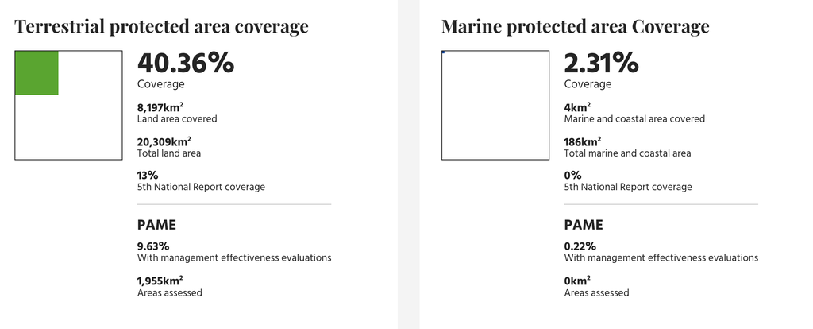

- The August 2020 update of the dataset tells us that there were 172 polygons added, 305 polygons removed, and 870 polygons updated for Slovenia. **The removal of polygons is likely why their score has decreased.**

## India -0.218:

- Their country page shows this much protected area:

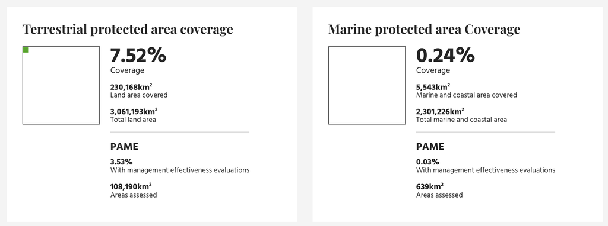

- **The February 2021 update of the dataset shows that 346 polygons in India were removed.**

I feel pretty confident that these changes are not due to a screw up, and just changes in source data. Although the Bouvet Island one does confuse me.